# Market Analysis : Cyclistic Bike share program

## 5. SHARE PHASE (Deliverable = Final report)

### **Final slideshow report :**

The Final report is created in a clear and easy to understand manner for the stakeholders - specifically, the marketing executives - by distilling the key insights from the analysis and providing actionable recommendations.

👉 **Final slideshow report can be viewed here :** [Click Here to view the Final Slideshow Report](https://docs.google.com/presentation/d/1t4PNAyT26frdq2fmbp1TTmcjhgb-E8NzZtqUuh3D1JU/edit?usp=sharing)

#### Additional Visualizations generated :

1. **Trip duration & Frequency : Stations from Top 10 Routes each (Annual members)**

```r
member_duration <- read.csv("member_top_routes_stations_durations_geocoded.csv")
member_trip <- read.csv("member_top_routes_stations_trips_geocoded.csv")

member_top_routes_stations_duration_trip <- bind_rows(member_duration, member_trip) %>%
  distinct(station_name, .keep_all = TRUE)

member_top_routes_stations_duration_trip
```

```
##                       station_name latitude longitude
## 1              Canal St & Adams St 41.87925 -87.64001
## 2        Columbus Dr & Randolph St 41.88461 -87.61953
## 3     Michigan Ave & Washington St 41.88388 -87.62469
## 4           Michigan Ave & Lake St 41.88605 -87.62435
## 5              Theater on the Lake 41.92718 -87.63074
## 6            Canal St & Madison St 41.88165 -87.63957
## 7     Clinton St & Washington Blvd 41.88341 -87.64114
## 8  Lakefront Trail & Bryn Mawr Ave 41.98404 -87.65230
## 9       Larrabee St & Kingsbury St 41.89774 -87.64288
## 10       Wacker Dr & Washington St 41.88329 -87.63652
## 11         Clinton St & Madison St 41.88278 -87.64120
## 12          State St & Randolph St 41.88469 -87.62778
## 13       LaSalle St & Jackson Blvd 41.87820 -87.63176
```

```r
## Create the map

map_member_route_stations <- leaflet(member_top_routes_stations_duration_trip) %>%
  addProviderTiles(providers$CartoDB.Positron) %>%
  addCircleMarkers(
    ~longitude, ~latitude,
    radius = 6,
    color = "blue",
    fillOpacity = 0.9,
    stroke = FALSE,
    popup = ~paste0(":</strong> ", station_name, "<br>"
    )
  ) %>%
  addControl(
    html = paste0(
      "<div style='text-align:left; padding:8px; font-size:12px; background:white; border-radius:8px;'>",
      "<strong>Trip duration & Frequency : Stations from Top 10 Routes each (Annual members)</strong><br>",
      paste0(
        member_top_routes_stations_duration_trip %>%
          mutate(label = paste0(" * ", station_name)) %>%
          pull(label),
        collapse = "<br>"
      ),
      "</div>"
    ),
    position = "topright"
  )

map_member_route_stations
```

[interactive chart not shown]

2. **(Horizontal bar charts) Total trip count & Total trip duration of Casual users by Bike route**

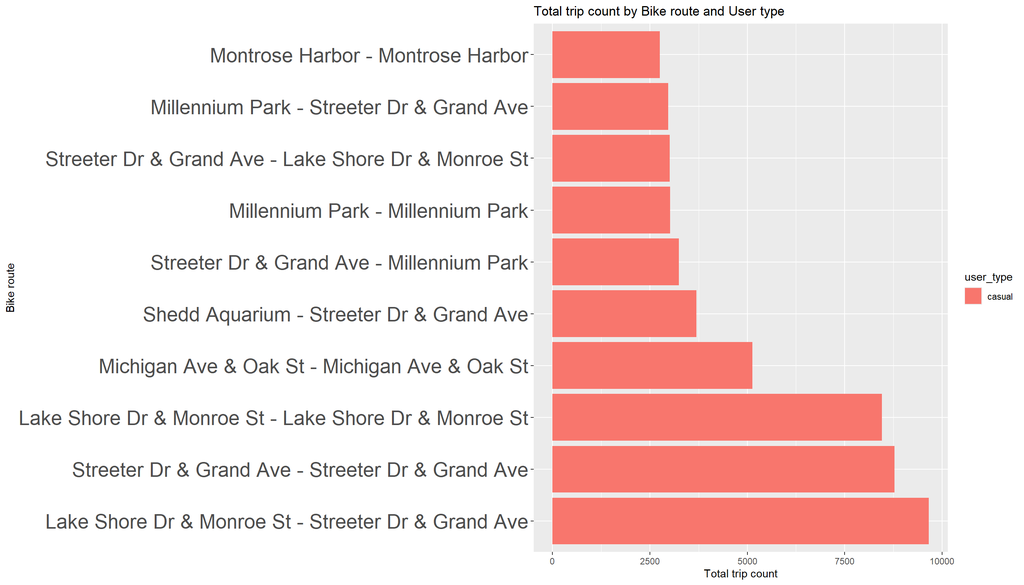

```r
ggplot(summary5_df %>%
  filter(user_type == 'casual') %>%
    arrange(total_trip_count), aes(y = forcats::fct_reorder(bike_route, -total_trip_count),
                        x = total_trip_count,
                        fill = user_type)) +
  geom_col(position = "identity") +
  labs(title = "Total trip count by Bike route and User type",
       x = "Total trip count",
       y = "Bike route")+
  theme(axis.text.y = element_text(size = 20))
```

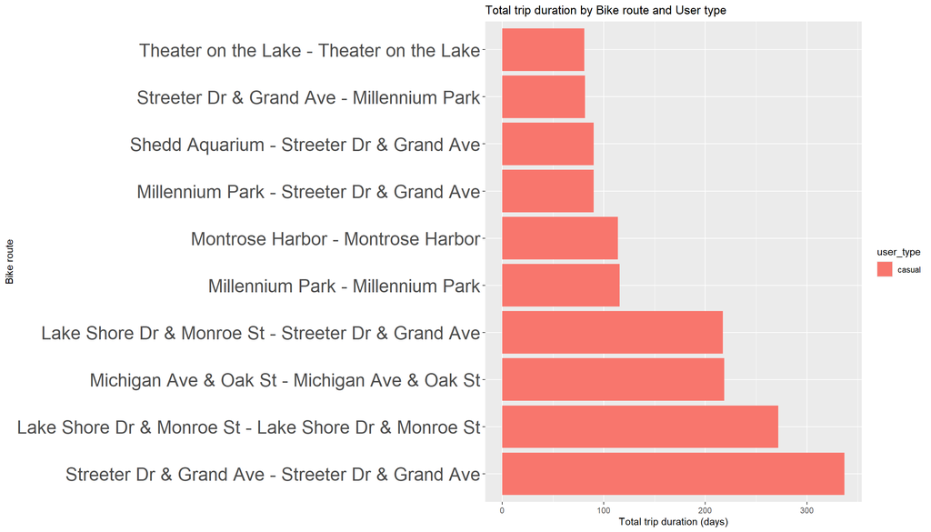

```r
ggplot(summary5_df_1 %>%
  filter(user_type == 'casual') %>%
    arrange(total_trip_duration), aes(y = forcats::fct_reorder(bike_route, -total_trip_duration),
                        x = total_trip_duration,
                        fill = user_type)) +
  geom_col(position = "identity") +
  labs(title = "Total trip duration by Bike route and User type",
       x = "Total trip duration (days)",
       y = "Bike route")+
  theme(axis.text.y = element_text(size = 20))
```

## 6. ACT PHASE (Deliverable = Top 3 recommendations based on the analysis)

Here are my Top 3 recommendations for the Marketing executives :

1. **Launch referral-based promotions to convert students into annual members on Chicago college campuses near the Lake Michigan shoreline during peak months from May to October.**
- Casual riders are primarily active in the 18–25 age range, and the top stations for casual riders are located along Chicago’s Lake Michigan shoreline.
2. **Offer seasonal weekend promotions from late spring through summer at bike stations along the Chicago shoreline, also targeting top routes of the casual riders.**
- Casual rider activity peaks on weekends and during late spring (May) through the summer season (June to September).
3. **Host contests for adult and middle-aged riders at top casual rider stations during peak months, offering discounted annual memberships as prizes along with mid-event campaigns highlighting the health and budget benefits of annual memberships.**
- Casual riders are highly active in the age range of 26-51 (Young adults, Middle-aged adults).

👉 Refer the Final slideshow report for more details : [Click Here to view the Final Slideshow Report](https://docs.google.com/presentation/d/1t4PNAyT26frdq2fmbp1TTmcjhgb-E8NzZtqUuh3D1JU/edit?usp=sharing)

## Remarks :

With the completion of this case study and the development of an infant problem solving system, I will now focus on solving more complex challenges while iteratively enhancing the system’s capabilities.

Ciao. 😉

**If you found this analysis ‘really’ interesting or not, you can get to know me or contact me 😊 :**

👉[LinkedIn : https://www.linkedin.com/in/r-amarthya-sreechand-3223351b4/](https://www.linkedin.com/in/r-amarthya-sreechand-3223351b4/).

📩Email : amarthyasreechand@gmail.com.